# Anaylsis of Impact of Major Storms and Weather Events

Zach Valadez

July 1, 2018

## Sympnosis

The goal of this anaylsis is to exlore the effect of severe storms and weather events in an area by using NOAA storm database, which covers events from 1950 and end in November 2011.  
We will look at how these storms and weather events have effected  
1. Fatalities and injuries  
2. Property and crops damage [NOAA storm Data](https://d396qusza40orc.cloudfront.net/repdata%2Fdata%2FStormData.csv.bz2)

## Data Processing

### Loading Data

We will first download the data we want to observe then make it into a data table to make it easier to work with.

```r
library(data.table)
library(ggplot2)

url <- "https://d396qusza40orc.cloudfront.net/repdata%2Fdata%2FStormData.csv.bz2"
download.file(url, paste0(getwd(),"/repdata%2Fdata%2FStormData.csv.bz2"))
stormDF <- read.csv(paste0(getwd(),"/repdata%2Fdata%2FStormData.csv.bz2"))

stormDT <- as.data.table(stormDF)
```

### Looking at Column Names

```r
colnames(stormDT)
```

```
##  [1] "STATE__"    "BGN_DATE"   "BGN_TIME"   "TIME_ZONE"  "COUNTY"
##  [6] "COUNTYNAME" "STATE"      "EVTYPE"     "BGN_RANGE"  "BGN_AZI"
## [11] "BGN_LOCATI" "END_DATE"   "END_TIME"   "COUNTY_END" "COUNTYENDN"
## [16] "END_RANGE"  "END_AZI"    "END_LOCATI" "LENGTH"     "WIDTH"
## [21] "F"          "MAG"        "FATALITIES" "INJURIES"   "PROPDMG"
## [26] "PROPDMGEXP" "CROPDMG"    "CROPDMGEXP" "WFO"        "STATEOFFIC"
## [31] "ZONENAMES"  "LATITUDE"   "LONGITUDE"  "LATITUDE_E" "LONGITUDE_"
## [36] "REMARKS"    "REFNUM"
```

### Subsetting Data

We now are going to subset the data and take out only what we are interested in.

```r
colsRemoved <- colnames(stormDT[, !c("EVTYPE", "FATALITIES", "INJURIES", "PROPDMG", "PROPDMGEXP",
                                     "CROPDMG", "CROPDMGEXP")])

stormDT[, c(colsRemoved) := NULL]

stormDT <- stormDT[(EVTYPE != "?" & (INJURIES > 0 | FATALITIES > 0 | PROPDMG > 0 | CROPDMG > 0)),
                   c("EVTYPE", "FATALITIES", "INJURIES", "PROPDMG", "PROPDMGEXP","CROPDMG", "CROPDMGEXP")]
```

### Converting Exponents Columns into Actual Exponents

Right now in our data table our exponent column is made up on different characters and not real expontents. This is true for exponent columns for PROPDMGEXP and CROPDMGEXP. This will help these columns look cleaner as well as to be used to calculate property crop damage cost.

```r
propDmgKey <- c("\"\"" = 10^0, "-" = 10^0, "+" = 10^0,"0" = 10^0,"1" = 10^1,"2" = 10^2,"3" = 10^3,
                "4" = 10^4,"5" = 10^5,"6" = 10^6,"7" = 10^7,"8" = 10^8,"9" = 10^9,"H" = 10^2,"K" = 10^3,
                 "M" = 10^6,"B" = 10^9)

cropDmgKey <- c("\"\"" = 10^0,"?" = 10^0, "0" = 10^0,"K" = 10^3,"M" = 10^6,"B" = 10^9)

stormDT[, PROPDMGEXP := propDmgKey[as.character(stormDT[,PROPDMGEXP])]]
stormDT[is.na(PROPDMGEXP), PROPDMGEXP := 10^0]

stormDT[, CROPDMGEXP := cropDmgKey[as.character(stormDT[,CROPDMGEXP])]]
stormDT[is.na(CROPDMGEXP), CROPDMGEXP := 10^0]
```

### Creating Cost Columns for Property and Crops

```r
stormDT <- stormDT[, .(EVTYPE, FATALITIES, INJURIES, PROPDMG, PROPDMGEXP, propCost = PROPDMG * PROPDMGEXP,
                       CROPDMG, CROPDMGEXP, cropCost = CROPDMG * CROPDMGEXP)]
```

### Total Property and Crop Damage Cost

```r
totalCostDT <- stormDT[, .(propCost = sum(propCost), cropCost = sum(cropCost),
                         total_cost = sum(propCost) + sum(cropCost)), by = .(EVTYPE)]
totalCostDT <- totalCostDT[order(-total_cost),]
totalCostDT <- totalCostDT[1:10, ]
head(totalCostDT, 5)
```

```
##               EVTYPE     propCost   cropCost   total_cost
## 1:             FLOOD 144657709807 5661968450 150319678257
## 2: HURRICANE/TYPHOON  69305840000 2607872800  71913712800
## 3:           TORNADO  56935880688  414953270  57350833958
## 4:       STORM SURGE  43323536000       5000  43323541000
## 5:              HAIL  15730367518 3025537890  18755905408
```

### Total Number of FATALITIES and Injuries

```r
totalInjuriesDT <- stormDT[, .(FATALITIES = sum(FATALITIES), INJURIES = sum(INJURIES),
                         total_injuries = sum(FATALITIES) + sum(INJURIES)), by = .(EVTYPE)]
totalInjuriesDT <- totalInjuriesDT[order(-total_injuries),]
totalInjuriesDT <- totalInjuriesDT[1:10, ]
head(totalInjuriesDT, 5)
```

```
##            EVTYPE FATALITIES INJURIES total_injuries
## 1:        TORNADO       5633    91346          96979
## 2: EXCESSIVE HEAT       1903     6525           8428
## 3:      TSTM WIND        504     6957           7461
## 4:          FLOOD        470     6789           7259
## 5:      LIGHTNING        816     5230           6046
```

## Results

### Events that caused the most injuries

First we will create a data table to help create a plot

```r
harmfulEvent <- melt(totalInjuriesDT, id.vars = "EVTYPE", variable.name = "harmfulThing")
head(harmfulEvent, 5)
```

```
##            EVTYPE harmfulThing value
## 1:        TORNADO   FATALITIES  5633
## 2: EXCESSIVE HEAT   FATALITIES  1903
## 3:      TSTM WIND   FATALITIES   504
## 4:          FLOOD   FATALITIES   470
## 5:      LIGHTNING   FATALITIES   816
```

Now we are going to make our plot.

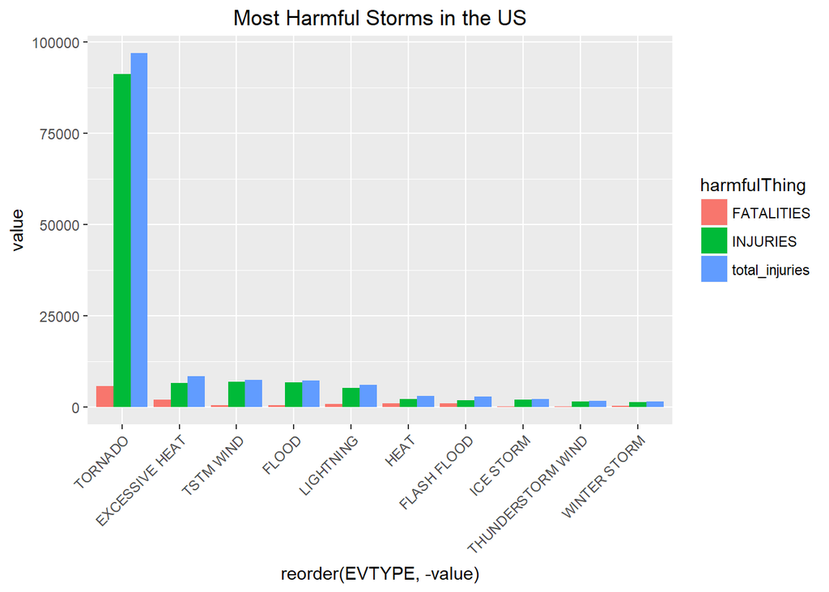

```r
healthPlot <- ggplot(harmfulEvent, aes(x = reorder(EVTYPE, -value), y = value))
healthPlot = healthPlot + geom_bar(stat = "identity", aes(fill = harmfulThing), position = "dodge") +
    labs(title = "Most Harmful Storms in the US", xlabs = "Event Type", ylabs = "Frequency Count") +
    theme(axis.text.x = element_text(angle = 45, hjust = 1), plot.title = element_text(hjust = 0.5))
healthPlot
```

### Events that caused the most damage

First we will create a data table to help create a plot once again

```r
destructiveEvent <- melt(totalCostDT, id.vars = "EVTYPE", variable.name = "destructiveThing")
head(destructiveEvent, 5)
```

```
##               EVTYPE destructiveThing        value
## 1:             FLOOD         propCost 144657709807
## 2: HURRICANE/TYPHOON         propCost  69305840000
## 3:           TORNADO         propCost  56935880688
## 4:       STORM SURGE         propCost  43323536000
## 5:              HAIL         propCost  15730367518
```

Now we are going to make our plot.

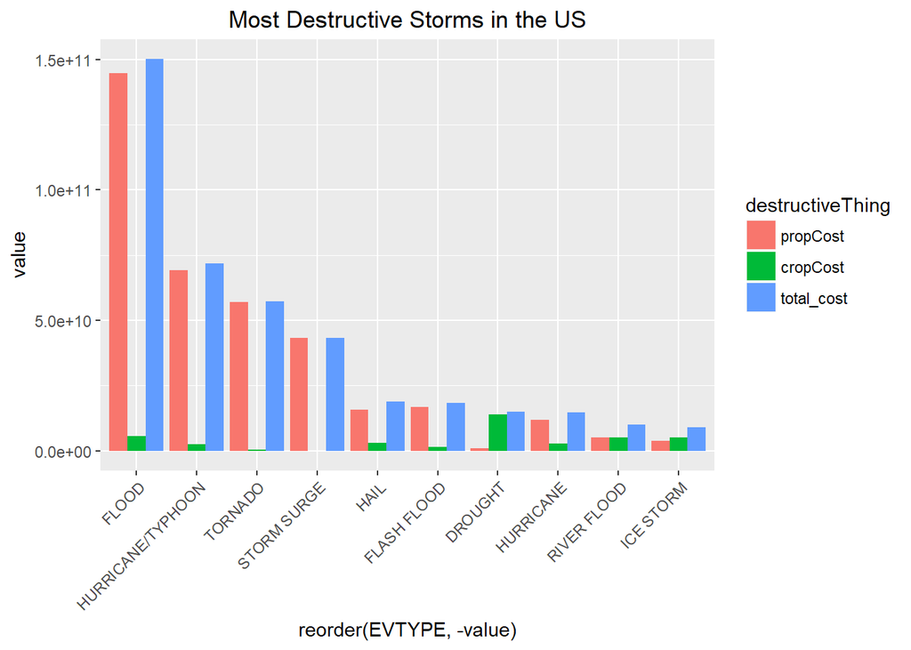

```r
costPlot <- ggplot(destructiveEvent, aes(x = reorder(EVTYPE, -value), y = value))
costPlot = costPlot + geom_bar(stat = "identity", aes(fill = destructiveThing), position = "dodge") +
    labs(title = "Most Destructive Storms in the US", xlabs = "Event Type", ylabs = "Cost (dollars)") +
    theme(axis.text.x = element_text(angle = 45, hjust = 1), plot.title = element_text(hjust = 0.5))
costPlot
```